# U6. Alfonsín

Primeros programas y deuda · Clase 26

Sebastian Freille

Universidad Nacional de Córdoba

# Apertura

## Dónde estamos

- En **diciembre de 1983**, la democracia recibe una economía endeudada, con inflación alta y una fuerte caída previa del ingreso por habitante.
- La crisis de 1982 cambió las condiciones externas: ya no era posible cubrir sistemáticamente los vencimientos con nuevos préstamos voluntarios.
- **Bernardo Grinspun** buscó recuperar empleo y salarios mientras reducía gradualmente la inflación. La expectativa era que la normalización política ayudara también a destrabar la economía.

**Idea clave**

La recuperación debía convivir con una transferencia de recursos al exterior. El Estado necesitaba conseguir ingresos en pesos y, además, los dólares para pagar su deuda.

Gerchunoff y Llach (2007), cap. 9, pp. 386–395.

## La pregunta de hoy

> ¿Por qué el gobierno no pudo combinar recuperación salarial, crecimiento y desinflación durante sus primeros quince meses?

**Para ordenar la discusión**

Vamos a distinguir la **herencia recibida**, el **diagnóstico inicial** y los **efectos de las medidas**. Dentro de la gestión de Grinspun hubo un giro: del estímulo a la demanda al ajuste acordado con el FMI.

## Mapa de la clase

1. **Bloque 1. La herencia:** democracia, expectativas y restricciones.
2. **Bloque 2. La deuda:** divisas, recursos fiscales y negociación.
3. **Bloque 3. Grinspun:** salarios, crédito y pautas de precios.
4. **Bloque 4. El fracaso:** ajuste, recesión y cambio de equipo.

Programa 2024, capítulo 6, apartado 6.3. Período central: diciembre de 1983–febrero de 1985, con una transición a marzo. El Plan Austral se desarrolla en la próxima clase.

# Bloque 1. La herencia

## [1.1] La promesa democrática

- El retorno constitucional abrió expectativas de recuperación del nivel de vida después de años de represión, crisis y deterioro económico.
- La consolidación institucional ocupaba un lugar central. El gobierno debía administrar demandas sociales y conflictos distributivos en un régimen de libertades recuperadas.
- La legitimidad electoral ampliaba el respaldo inicial, pero **no cancelaba vencimientos, no generaba reservas ni equilibraba las cuentas públicas**.

**Política y economía**

Gerchunoff y Llach interpretan el optimismo inicial como una subestimación de problemas estructurales. Es una evaluación de los autores, no una explicación que vuelva inevitable todo lo ocurrido después.

Gerchunoff y Llach (2007), pp. 391–394.

## [1.2] Una herencia que se reforzaba

| Problema | Restricción para el nuevo gobierno |
| --- | --- |
| **Deuda externa** | Conseguir divisas sin acceso normal a crédito |
| **Estancamiento** | Recuperar ingresos con poca expansión de la producción |
| **Déficit público** | Financiar gastos e intereses con recursos escasos |
| **Inflación persistente** | Coordinar contratos y preservar la demanda de pesos |
| **Baja inversión** | Ampliar capacidad productiva y exportadora |

- Estos problemas interactuaban: una recesión podía mejorar las importaciones y empeorar la recaudación al mismo tiempo.

Gerchunoff y Llach (2007), pp. 386–393. Síntesis de restricciones, sin atribuir todos los desequilibrios a una única causa.

## [1.3] El ajuste antes de Alfonsín

- Entre 1980 y 1983, los pagos al exterior por **intereses y utilidades** pasaron de **2,2 % a 9,4 % del PBI**, según las cifras presentadas por Gerchunoff y Llach.
- En 1983, las importaciones y la inversión estaban aproximadamente en **la mitad de sus valores de 1980**. El superávit externo había exigido una fuerte compresión del gasto.
- El PBI por habitante de 1983 era algo inferior al de 1974. Había demandas de recuperación acumuladas antes de la llegada del radicalismo.

Gerchunoff y Llach (2007), p. 391. Las cifras de intereses y utilidades no equivalen a amortizaciones ni al servicio de la deuda pública exclusivamente.

## [1.4] ¿Otra vez la experiencia de Illia?

| Referencia de los años sesenta | Condiciones de 1983–1984 |
| --- | --- |
| Recuperar empleo y salarios mediante demanda | Recuperar demanda con una transferencia externa elevada |
| Utilizar capacidad productiva disponible | Utilizarla requería insumos y financiamiento |
| Administrar una inflación menor | Coordinar una economía habituada a aumentos mucho más altos |
| Un equipo con experiencia de gobierno | Una experiencia adquirida bajo otras restricciones |

**La comparación relevante**

Que una política haya acompañado una expansión en otro momento no asegura que funcione con otra deuda, otra inflación y otro acceso al crédito.

Gerchunoff y Llach (2007), pp. 393–394. Comparación didáctica del diagnóstico inicial.

## [1.5] Los primeros quince meses

| Etapa | Prioridad e instrumentos | Dificultad |
| --- | --- | --- |
| **Diciembre de 1983** | Recomposición salarial y estímulo a la demanda | Compatibilizar recuperación y estabilización |
| **Primeros meses de 1984** | Pautas de precios, salarios, tarifas y dólar | Incumplimientos y compensaciones salariales |
| **Durante 1984** | Indexación y negociación externa | Aceleración de precios y falta de financiamiento |
| **Finales de 1984** | Acuerdo con el FMI y giro contractivo | Recesión y persistencia inflacionaria |
| **Febrero–marzo de 1985** | Cambio de equipo y nuevo diagnóstico | Preparar una estabilización diferente |

Gerchunoff y Llach (2007), pp. 393–397. «Quince meses» es la periodización aproximada del programa: Grinspun dejó el ministerio en febrero de 1985.

# Bloque 2. El problema de la deuda

## [2.1] El cambio de las reglas externas

- Durante los años setenta, la abundancia de crédito había permitido financiar desequilibrios y renovar obligaciones.
- La suba de las tasas internacionales encareció la deuda acumulada. Desde la crisis de 1982, los acreedores se resistían a aumentar su exposición.
- Los países deudores debían **pagar más con menos financiamiento**. En América Latina, las transferencias netas de recursos cambiaron de signo.

**La deuda como restricción de flujo**

El stock importa, pero también importan la tasa de interés, los vencimientos y cuánto se puede refinanciar. Dos deudas del mismo monto pueden exigir pagos inmediatos muy diferentes.

Gerchunoff y Llach (2007), pp. 386–390.

## [2.2] Intereses y vencimientos

| Concepto | Ejemplo en millones de dólares |
| --- | --- |
| **Deuda al inicio** | 100 |
| **Intereses del año, a una tasa de 10 %** | 10 |
| **Capital que vence ese año** | 20 |
| **Servicio total** | 30 |
| **Nuevos desembolsos** | 15 |
| **Necesidad neta de divisas** | 15 |

- Si la tasa sube a **15 %**, manteniendo los demás valores, la necesidad neta sube a **20**. Si además no hay nuevos desembolsos, sube a **35**.

Ejemplo propio para interpretar Gerchunoff y Llach (2007), pp. 386–387. Cifras ilustrativas, sin atrasos, comisiones ni cambios de valuación.

## [2.3] La transferencia al exterior

En una economía simplificada, el producto se distribuye entre gasto interno y exportaciones netas:

$$Y=C+I+G+(X-M)$$

- $Y$: producto. $C$, $I$ y $G$: consumo, inversión y gasto público. $X-M$: exportaciones netas de bienes y servicios.
- Si hay que elevar $X-M$ y el producto no crece, debe reducirse alguna parte del **gasto interno**.
- Expandir exportaciones demanda tiempo. Recortar importaciones puede ser más rápido, pero afecta producción cuando faltan insumos y equipos.

Identidad simplificada y aplicación didáctica a Gerchunoff y Llach (2007), pp. 386–388. La identidad no determina por sí sola cómo ocurre el ajuste.

## [2.4] El límite de comprimir importaciones

- Al principio se pueden reducir algunas compras prescindibles o sustituibles. Pero una economía protegida ya importaba muchos bienes difíciles de reemplazar.
- Si una fábrica necesita piezas importadas para producir, recortarlas también reduce producción, empleo y recaudación.
- Menos importaciones de equipos alivian las cuentas actuales y pueden debilitar la capacidad de exportar en el futuro.

**La trampa**

El ajuste que permite pagar hoy puede reducir la capacidad de pagar mañana. El resultado depende de qué gasto cae y de cuánto tarda en responder la producción exportable.

Gerchunoff y Llach (2007), pp. 387–391.

## [2.5] La transferencia al Estado

- Una parte sustancial de la deuda era pública. El Estado tenía que apropiarse de recursos internos para atender sus obligaciones externas.
- Los dólares de una exportación podían pertenecer a un productor privado. **Que ingresaran al país no significaba que fueran ingresos del Tesoro**.
- El gobierno podía obtener recursos con impuestos, menor gasto o financiamiento. Cada alternativa tenía costos y límites en una economía estancada.

**Dos cuentas distintas**

El superávit comercial ayuda a conseguir divisas. El superávit fiscal ayuda a financiar su compra. El primero puede existir mientras el Estado sigue en déficit.

Gerchunoff y Llach (2007), pp. 388–392. Exposición didáctica de las dimensiones externa y fiscal de la deuda.

## [2.6] Hay dólares, faltan pesos

| Economía simplificada | Resultado |
| --- | --- |
| **Exportaciones privadas** | US$ 100 |
| **Importaciones privadas** | US$ 70 |
| **Divisas disponibles para transferir** | US$ 30 |
| **Pago externo del Estado** | US$ 30 |
| **Costo de comprarlas a 10 pesos por dólar** | 300 pesos |

- Supongamos que el Estado tiene **200 pesos** disponibles: le faltan **100**. El superávit comercial no resolvió su financiamiento.
- Emitir esos pesos permite una compra nominal, pero puede presionar precios y dólar si no aumenta la demanda de dinero.

Ejemplo propio, sin otros flujos externos ni variaciones de reservas. No son magnitudes históricas. Basado en Gerchunoff y Llach (2007), pp. 388–392.

## [2.7] Devaluar: alivio externo y costo fiscal

| Efecto posible | Mecanismo |
| --- | --- |
| **Mejora comercial** | Exportar rinde más en pesos e importar se encarece |
| **Presión sobre costos** | Suben insumos importados y bienes transables |
| **Pérdida salarial** | Los precios pueden adelantarse a los salarios |
| **Mayor carga fiscal** | El Estado necesita más pesos para pagar los mismos dólares |

- La respuesta depende de las cantidades exportadas e importadas, los impuestos y el traslado a precios. La mejora comercial no es instantánea ni asegura equilibrio fiscal.

Gerchunoff y Llach (2007), pp. 387–389 y 392. Mecanismos analíticos, manteniendo constantes otras condiciones.

## [2.8] La negociación con los acreedores

- El gobierno esperaba que la recuperación democrática favoreciera un trato más flexible. La negociación inicial tuvo un tono confrontativo.
- Hubo apoyo político externo y ayuda financiera de emergencia, pero el financiamiento seguía condicionado a un acuerdo de ajuste con el FMI.
- **Bancos acreedores, FMI y gobiernos** cumplían papeles distintos: renovar créditos, acordar metas y facilitar apoyos no eran una misma decisión.

**El margen de negociación**

Renegociar puede distribuir pagos en el tiempo. Si no cambia suficientemente la carga, el problema reaparece cuando vence el alivio.

Gerchunoff y Llach (2007), pp. 390 y 394–395.

## [2.9] Deuda e inflación

- La deuda pública externa elevaba las necesidades de recursos en una economía con crédito restringido y recaudación débil.
- La emisión ofrecía financiamiento inmediato. La inflación reducía el poder adquisitivo de los saldos monetarios y estimulaba la búsqueda de activos alternativos.
- Si el público mantenía menos dinero real, la base sobre la que recaía el impuesto inflacionario se achicaba. Financiar un mismo gasto se volvía más difícil.

**No hay una equivalencia automática**

Una deuda mayor no se convierte mecánicamente en una tasa de inflación. Importan la respuesta fiscal, el financiamiento disponible y la demanda de dinero.

Gerchunoff y Llach (2007), pp. 388–392.

# Bloque 3. El programa de Grinspun

## [3.1] El diagnóstico inicial

- La prioridad era **recuperar empleo y salario real**. El gasto público y el crédito barato debían sostener una expansión de la demanda.
- La inflación se enfrentaría de forma gradual mediante pautas sobre las principales variables nominales.
- El programa suponía que se podía estimular la actividad y recomponer ingresos mientras se moderaban las remarcaciones y se obtenía alivio externo.

**La apuesta**

Una economía con capacidad ociosa podía producir más. Pero esa capacidad no eliminaba las restricciones de divisas, financiamiento y coordinación de precios.

Gerchunoff y Llach (2007), pp. 393–395.

## [3.2] Objetivos e instrumentos

| Objetivo | Instrumento | Condición para sostenerlo |
| --- | --- | --- |
| **Recuperar salario real** | Aumento inicial y ajustes posteriores | Que precios no absorbieran la recomposición |
| **Estimular actividad** | Crédito barato y gasto público | Financiamiento y disponibilidad de insumos |
| **Bajar inflación** | Pautas de precios, salarios, tarifas y dólar | Cumplimiento y consistencia fiscal y monetaria |
| **Aliviar pagos externos** | Negociación de la deuda | Acuerdo y desembolsos efectivos |

Gerchunoff y Llach (2007), pp. 394–395. Síntesis del programa inicial.

## [3.3] Las pautas de ingresos

- Después de un aumento inicial de salarios, el gobierno buscó dirigir la evolución de **precios, salarios, tarifas y tipo de cambio** mediante pautas.
- La intención era desacelerar los aumentos sin una contracción abrupta del empleo y del consumo.
- El gobierno tenía distinto control sobre cada variable. Los precios que escapaban a las directivas podían adelantarse a los salarios regulados.

**Coordinación y precios relativos**

Una pauta nominal indica cuánto puede subir una variable. Para sostener un salario real o un tipo de cambio real importa también cuánto suben las demás.

Gerchunoff y Llach (2007), p. 394.

## [3.4] Recuperar y conservar el salario

$$\frac{w_t}{w_{t-1}}=\frac{1+g_W}{1+\pi}$$

- $w$: salario real. $g_W$: aumento del salario nominal. $\pi$: inflación del mismo período.
- Si el salario sube **20 %** y los precios **25 %**, el salario real cae **4 %**: $1,20/1,25=0,96$.
- Para reparar esa pérdida después hay que ajustar nuevamente el salario. Si los precios vuelven a adelantarse, comienza otra ronda de compensación.

Identidad y ejemplo propios para interpretar las compensaciones descriptas en Gerchunoff y Llach (2007), p. 394. Porcentajes ilustrativos.

## [3.5] De las pautas a la indexación

- El incumplimiento de las directivas de precios obligó a otorgar aumentos salariales retroactivos para compensar la pérdida de poder adquisitivo.
- Luego, la compensación se automatizó mediante indexación salarial. La política de ingresos pasó a **seguir la inflación pasada**.
- Esa regla protegía ingresos frente a aumentos previos, pero dificultaba bajar conjuntamente el ritmo de salarios y precios.

**El cambio de función**

La pauta aspiraba a orientar la inflación futura. La indexación buscaba reparar la inflación ya ocurrida. La segunda podía reproducirla si no cambiaban las demás condiciones.

Gerchunoff y Llach (2007), pp. 394 y 396–397.

## [3.6] La inercia, con una cuenta sencilla

| Momento | Decisión ilustrativa |
| --- | --- |
| **Mes anterior** | Los precios aumentaron 20 % |
| **Salarios actuales** | Se ajustan 20 % para compensar |
| **Empresas** | Consideran costos y aumentos esperados de otros precios |
| **Otros contratos** | Toman la inflación pasada como referencia |

- Si todos esperan aumentos cercanos al **20 %**, frenar unilateralmente el propio precio o ingreso puede resultar costoso.
- La indexación explica persistencia. Para explicar una **aceleración** también hay que examinar shocks, pujas y políticas que permiten convalidar los aumentos.

Ejemplo propio basado en Gerchunoff y Llach (2007), pp. 394 y 396–397. No es un modelo completo de determinación de precios.

## [3.7] Dólar y tarifas como contención

- Si el dólar aumenta menos que los precios internos, puede ayudar transitoriamente al poder de compra. También puede reducir la rentabilidad de exportar.
- Si las tarifas quedan detrás de los costos, los servicios públicos contienen algunos precios, pero sus empresas necesitan cubrir la diferencia.
- Recuperar después esos precios relativos produce nuevos aumentos de costos. Las compensaciones salariales pueden propagar el efecto.

**El costo de postergar**

Contener un precio administrado puede aliviar el índice hoy. La sostenibilidad depende de cómo se financia la diferencia y de cómo se corrige después.

Gerchunoff y Llach (2007), pp. 394–396. Explicación de las tensiones entre recuperación salarial, apreciación y correcciones posteriores.

## [3.8] La aceleración de 1984

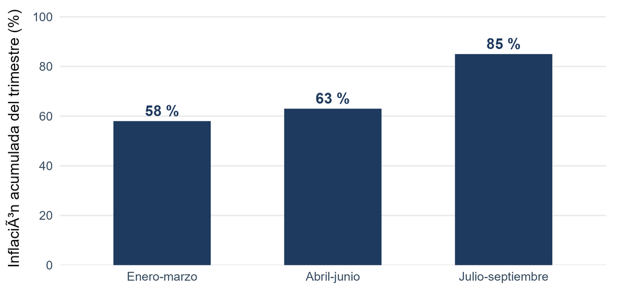

Gerchunoff y Llach (2007), p. 394. Variaciones acumuladas en cada trimestre, no tasas mensuales ni anualizadas. Gráfico elaborado con los tres valores publicados en el texto.

## [3.9] Recuperación salarial y conflicto

- Gerchunoff y Llach señalan una **recuperación del salario real en 1984**, junto con una inflación muy elevada y una economía que marchaba hacia la recesión.
- La mejora de ingresos no eliminaba el conflicto sindical: también estaban en disputa las políticas del gobierno hacia las organizaciones gremiales.
- La apreciación afectaba al agro y la incertidumbre sobre el programa dificultaba acuerdos con empresarios. La concertación reunió demandas que no formaban un programa común.

**El resultado distributivo no cerraba el programa**

Una recuperación salarial podía ser real y, al mismo tiempo, difícil de sostener. Evaluarla exige mirar actividad, inflación, sector externo y financiamiento público.

Gerchunoff y Llach (2007), p. 395. La recuperación salarial no implica una mejora uniforme de todos los ingresos ni de todos los trabajadores.

# Bloque 4. El giro y el fracaso

## [4.1] El acuerdo con el FMI

- A fines de 1984, todavía con Grinspun, el gobierno acordó con el FMI. La estabilización ganó prioridad frente al impulso inicial al consumo.
- El cambio incluyó **devaluación, aumentos de tarifas y restricción monetaria**, junto con recortes de gasto.
- Las correcciones buscaban mejorar el sector externo y las cuentas públicas. También modificaban precios relativos y reducían ingresos reales.

Gerchunoff y Llach (2007), pp. 395–396.

## [4.2] Dos etapas, un mismo ministro

| Dimensión | Programa inicial | Giro de fines de 1984 |
| --- | --- | --- |
| **Prioridad inmediata** | Recuperación de empleo y salarios | Contener inflación y desequilibrios |
| **Demanda** | Crédito barato y gasto | Mayor restricción monetaria y fiscal |
| **Ingresos** | Recomposición, pautas y compensación | Corrección de tarifas y dólar |
| **Deuda** | Búsqueda de mejores condiciones | Acuerdo con el FMI como condición financiera |
| **Problema persistente** | Pautas incumplidas e inflación | Recesión con desinflación insuficiente |

Gerchunoff y Llach (2007), pp. 394–396. Comparación de orientaciones, no de dos programas aplicados de manera perfectamente uniforme.

## [4.3] El costo de corregir precios

- Una devaluación o un aumento tarifario pueden mejorar ingresos públicos o incentivos externos y, a la vez, **elevar el nivel de precios inicialmente**.
- Si los contratos reproducen la inflación anterior, ese aumento puede trasladarse a salarios y otros precios durante varios períodos.
- Con demanda más débil, las empresas también ajustan ventas, producción y empleo. La inflación puede tardar en responder mientras la actividad ya cae.

**Nivel y tasa**

Un salto único de un precio no implica inflación permanente. La persistencia depende de su propagación, las expectativas y las políticas fiscal y monetaria.

Gerchunoff y Llach (2007), pp. 395–397. Interpretación de los mecanismos del ajuste y de la inflación inercial.

## [4.4] Una mejora que no se sostuvo

- Gerchunoff y Llach describen una moderación inicial del déficit y del aumento de precios tras el giro contractivo.
- Machinea señala que la desinflación fue insuficiente, la actividad cayó y no se cumplieron las metas fiscales del FMI. La inflación volvió a aumentar a comienzos de 1985.
- No hay contradicción entre una mejora transitoria y el fracaso estabilizador: importa si cambia de forma duradera el ritmo de precios y su financiamiento.

Gerchunoff y Llach (2007), pp. 395–396; Machinea (1990), sección II.1, pp. 13–14. Se distinguen el alivio inicial y su falta de continuidad.

## [4.5] Por qué fracasaron los primeros intentos

| Problema | Consecuencia |
| --- | --- |
| **Subestimación de la herencia** | La reactivación se apoyó en un margen externo y fiscal escaso |
| **Pautas sin coordinación efectiva** | Compensaciones e indexación reemplazaron la desaceleración |
| **Financiamiento restringido** | La deuda siguió condicionando las decisiones internas |
| **Correcciones de precios relativos** | El ajuste tuvo efectos inflacionarios inmediatos |
| **Inercia y conflicto distributivo** | Contraer demanda resultó costoso y no produjo estabilidad duradera |

Síntesis interpretativa de Gerchunoff y Llach (2007), pp. 391–397. Los mecanismos se complementan, no identifican efectos causales separados.

## [4.6] El relevo de Grinspun

- En **febrero de 1985**, Juan Vital Sourrouille reemplazó a Grinspun. Su equipo provenía de la Secretaría de Planificación.
- Machinea relata que el nuevo ministro no controlaba inicialmente todas las áreas económicas. La elaboración del programa antiinflacionario comenzó a mediados de marzo.
- El cambio de ministro abrió una nueva etapa, pero la estabilización no estuvo lista el día del relevo.

Gerchunoff y Llach (2007), p. 396; Machinea (1990), secciones II.1–II.2, pp. 14–15. Machinea escribe desde la experiencia del equipo económico.

## [4.7] El diagnóstico que abre otra etapa

- El nuevo equipo reconocía la importancia del **déficit fiscal y la emisión** para sostener la inflación en el largo plazo.
- También enfatizaba la **inercia**: contratos, decisiones de precios y expectativas tomaban como referencia la inflación pasada.
- Una estrategia debía abordar ambas dimensiones. Corregir las cuentas sin coordinar la desinflación podía ser muy recesivo. Coordinar precios sin financiamiento sostenible tampoco alcanzaba.

**La pregunta para el Austral**

¿Cómo lograr que todos dejen de ajustar por la inflación pasada al mismo tiempo que cambia la forma de financiar al Estado?

Gerchunoff y Llach (2007), pp. 396–397. Introducción al diagnóstico del Plan Austral, cuyo diseño se estudia en la próxima clase.

# Cierre

## Un caso para discutir

Un país tiene superávit comercial, deuda pública en dólares y déficit fiscal. El gobierno propone devaluar, congelar tarifas y compensar íntegramente los salarios por la inflación pasada.

1. ¿Qué parte del problema de pagos podría aliviar la devaluación?
2. ¿Qué puede pasar con los pesos necesarios para pagar la deuda pública?
3. ¿Cómo se financia la diferencia entre tarifas y costos?
4. ¿Qué mecanismo transmite los aumentos de hoy al mes siguiente?

Caso hipotético de integración. No describe un paquete histórico aplicado exactamente de esta forma.

## Ideas fuerza

1. La democracia recibió una economía con demandas de recuperación y un margen externo y fiscal muy limitado.
2. La deuda exigía una **doble transferencia**: recursos al Estado y recursos al exterior.
3. Grinspun buscó reactivar y desinflar gradualmente. El incumplimiento de las pautas y la indexación debilitaron esa combinación.
4. El giro de fines de 1984 corrigió instrumentos, pero no logró una estabilización duradera y profundizó las dificultades de actividad.
5. El diagnóstico posterior combinó consistencia fiscal y monetaria con coordinación de expectativas e ingresos.

## Preguntas para llevarse

- ¿Por qué la crisis de deuda no se resuelve necesariamente con superávit comercial?
- ¿Cómo puede una devaluación ayudar al sector externo y complicar al Tesoro?
- ¿Por qué la experiencia de Illia era una referencia insuficiente en 1983?
- ¿Qué diferencia hay entre una pauta salarial y la indexación por inflación pasada?
- ¿Por qué la recuperación salarial de 1984 no demuestra que el programa fuera sostenible?
- ¿Qué cambió a fines de 1984 y qué problemas persistieron hasta el relevo de Grinspun?

## Lecturas

- **Gerchunoff, P. y Llach, L. (2007).** *El ciclo de la ilusión y el desencanto*, cap. 9, «La democracia y el difícil gobierno de la economía (1983–1989)», especialmente **pp. 386–397**. Deuda y herencia: pp. 386–393. Gestión inicial: pp. 393–396.
- **Machinea, J. L. (1990).** *Stabilization under Alfonsin’s Government: A Frustrated Attempt*, Documentos CEDES 42, **secciones II.1–II.3, pp. 12–17**. [Texto en CEDES](https://repositorio.cedes.org/handle/123456789/3345).

Programa 2024, capítulo 6: Gerchunoff y Llach es bibliografía obligatoria y Machinea, complementaria. La numeración de páginas corresponde a las páginas impresas de las obras.

## La próxima etapa

> El gradualismo no logró coordinar la desinflación. ¿Podía un cambio simultáneo de reglas cortar la inercia sin provocar una recesión todavía mayor?
- **Plan Austral:** medidas iniciales, corrección fiscal, anclas nominales y contratos.
- Después: flexibilización, erosión del programa y crisis inflacionaria.

Continuación del apartado 6.3 del Programa 2024 y clase 27 del mapa temático. Gerchunoff y Llach (2007), cap. 9; Machinea (1990).